# Visualización de datos

```r
# Puedo ver la función de densidad de una variable continua
```

2. Ejecuta este código en tu mente y predice cómo se verá el output. Luego, ejecuta el código en R y verifica tus predicciones. Se representa dos variables continuas x e y, además, se asigna una estética para la variable categórica traccion con color, en un gráfico de dispersión y una línea suavizada ajustada a los datos sin los intervalos de confianza.

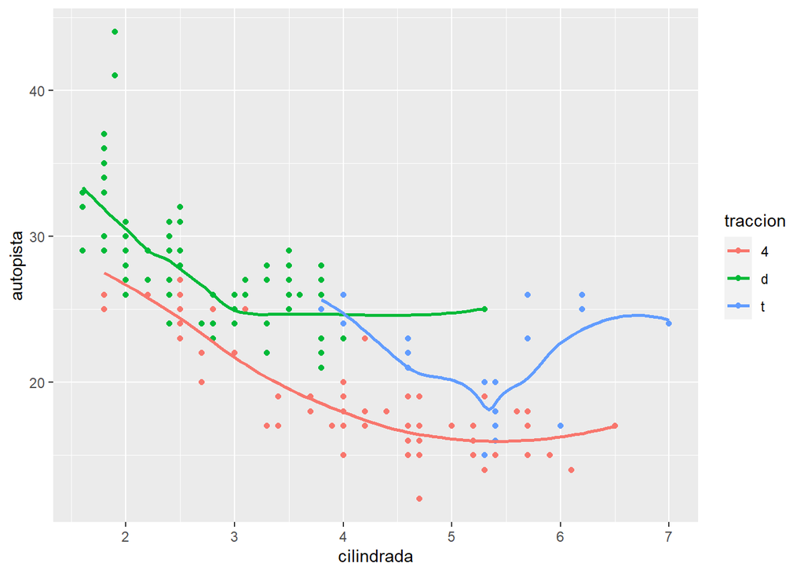

```r
ggplot(data = millas, mapping = aes(x = cilindrada, y = autopista, color = traccion)) +
  geom_point() +
  geom_smooth(se = FALSE)
```

3. ¿Qué muestra show.legend = FALSE? ¿Qué pasa si lo quitas? ¿Por qué crees que lo utilizamos antes en el capítulo? show.legend activa la leyenda de la estética, si la quitamos, toma su valor por default que es TRUE, y como resultado podremos observar la leyenda a la par del gráfico.

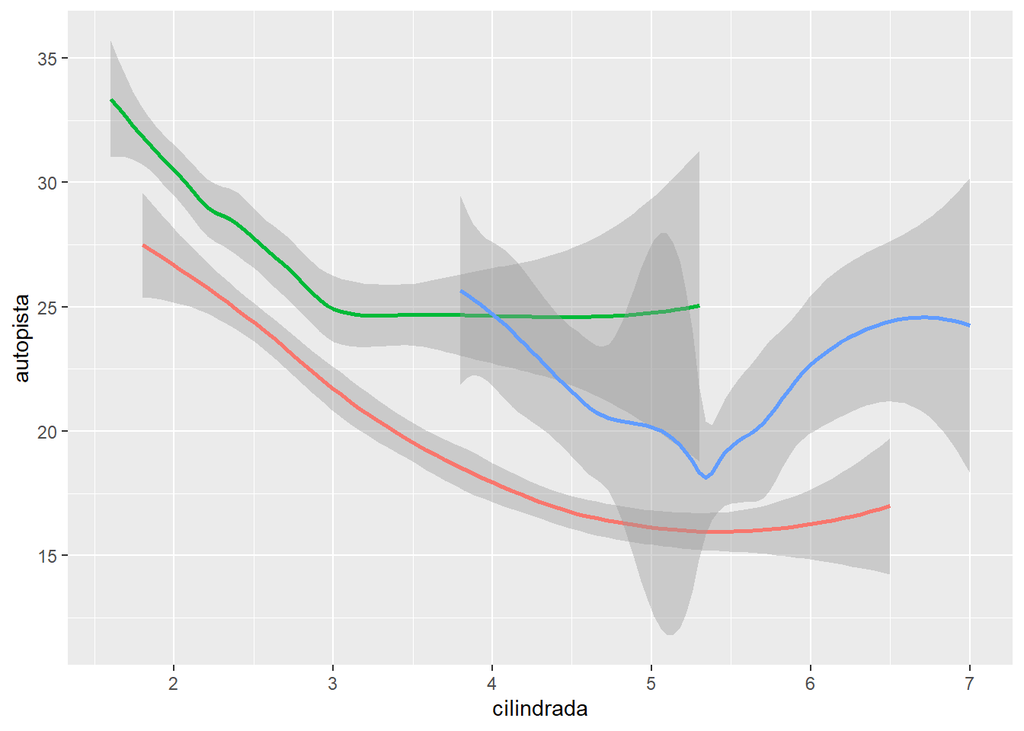

```r
ggplot(data = millas) +
  geom_smooth(
    mapping = aes(x = cilindrada, y = autopista, color = traccion),
    show.legend = FALSE
    )
```

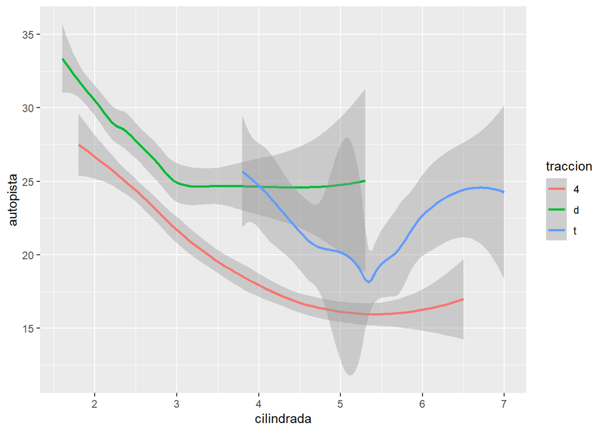

```r
ggplot(data = millas) +
  geom_smooth(
    mapping = aes(x = cilindrada, y = autopista, color = traccion))
```

4. ¿Qué hace el argumento se en geom_smooth()? Muestra el intervalo de confianza alrededor línea de suavizado, se = True es el valor por default.

```r
?geom_smooth
```

5. ¿Se verán distintos estos gráficos? ¿Por qué sí o por qué no? Se observan gráficos iguales, dado que las especificaciones en ggplot, se extienden a los objetos geométricos. Se obtiene igual resultado, si las especificaciones se realizan dentro de cada obtjeto.

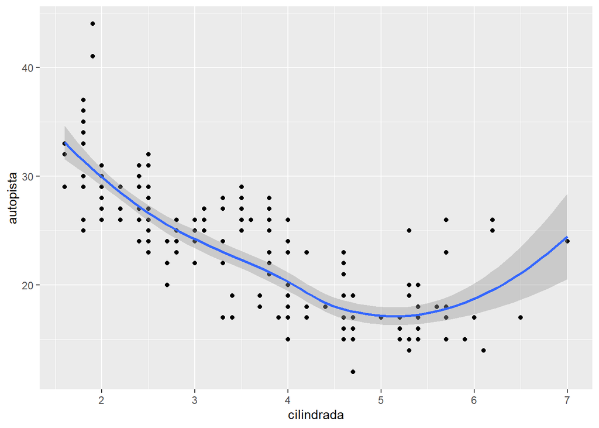

```r
ggplot(data = millas, mapping = aes(x = cilindrada, y = autopista)) +
  geom_point() +
  geom_smooth()
```

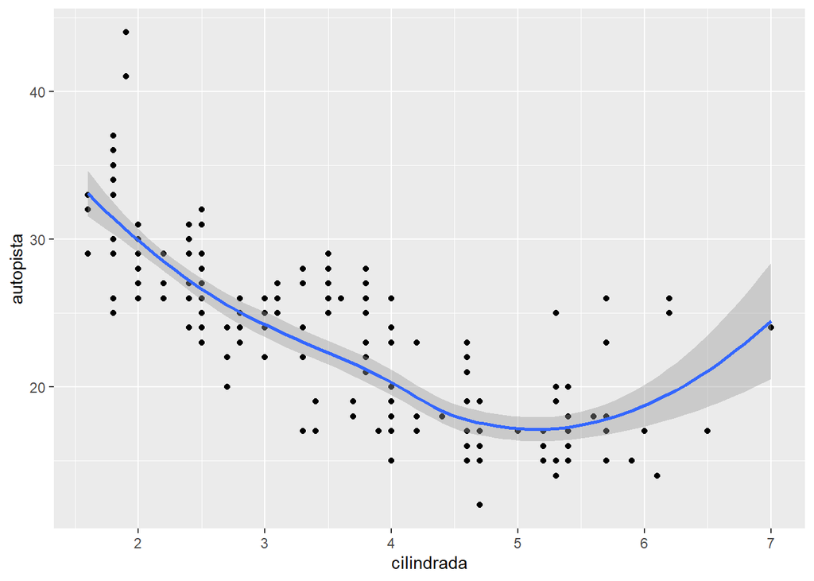

```r
ggplot() +
  geom_point(data = millas, mapping = aes(x = cilindrada, y = autopista)) +
  geom_smooth(data = millas, mapping = aes(x = cilindrada, y = autopista))
```

6. Recrea el código R necesario para generar los siguientes gráficos:

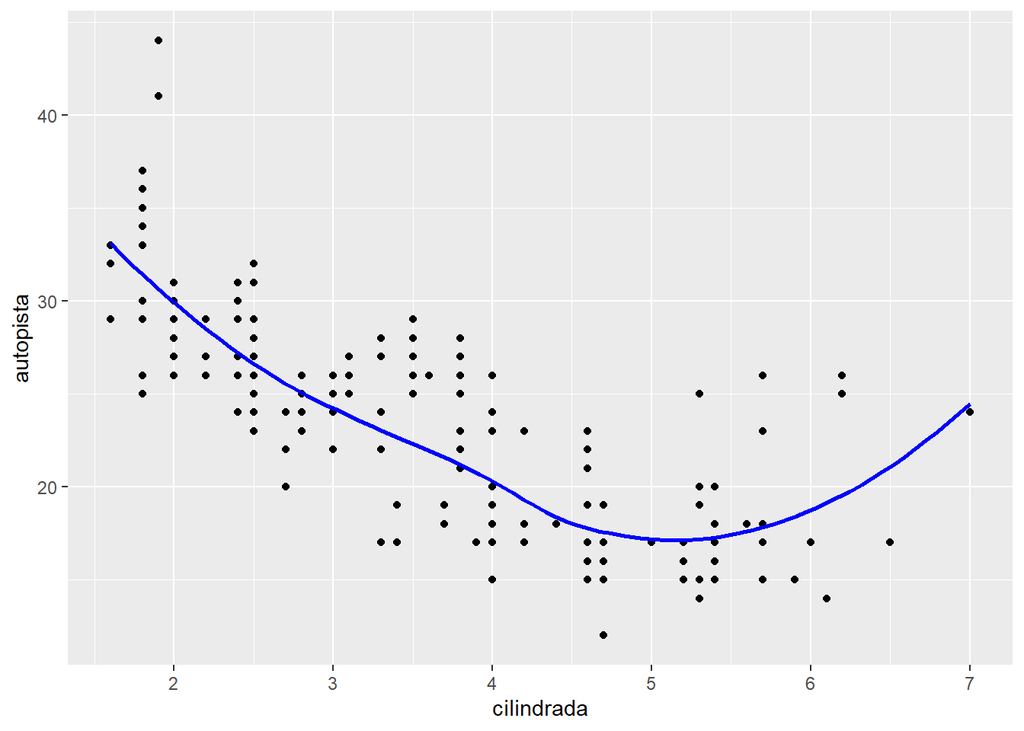

```r
# Primer gráfico
ggplot() +
  geom_point(data = millas, mapping = aes(x = cilindrada, y = autopista)) +
  geom_smooth(data = millas, mapping = aes(x = cilindrada, y = autopista), color= "blue", se=FALSE)
```

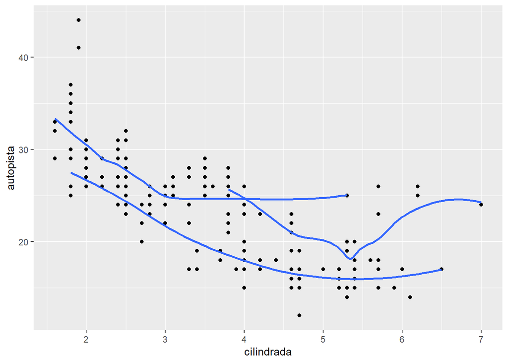

```r
# Segundo gráfico
ggplot() +
  geom_point(data = millas, mapping = aes(x = cilindrada, y = autopista)) +
  geom_smooth(data = millas, mapping = aes(x = cilindrada, y = autopista, group = traccion), se = FALSE)
```

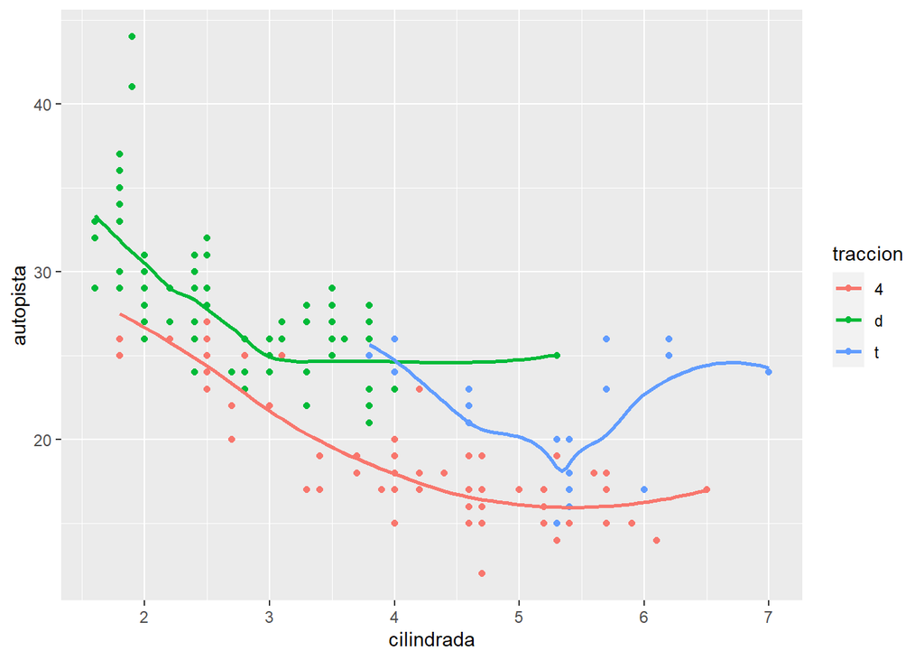

```r
# Tercer gráfico
ggplot(data = millas, mapping = aes(x = cilindrada, y = autopista, color = traccion)) +
  geom_point() +
  geom_smooth(se = F)
```

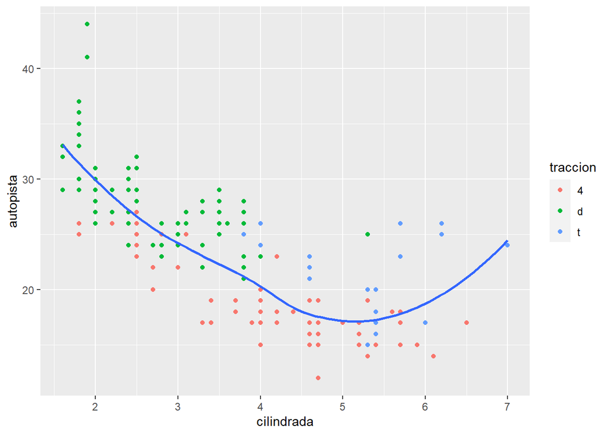

```r
# Cuarto gráfico
ggplot(data = millas) +
  geom_point(mapping = aes(x = cilindrada, y = autopista, color = traccion))+
  geom_smooth(mapping = aes(x = cilindrada, y = autopista), se = F)
```

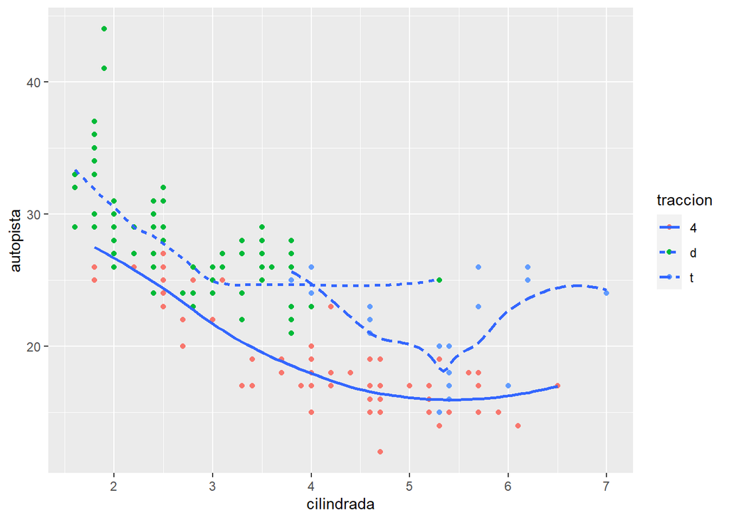

```r
# Quinto gráfico
ggplot(data = millas) +
  geom_point(mapping = aes(x = cilindrada, y = autopista, color = traccion))+
  geom_smooth(mapping = aes(x = cilindrada, y = autopista, linetype = traccion), se = F)
```

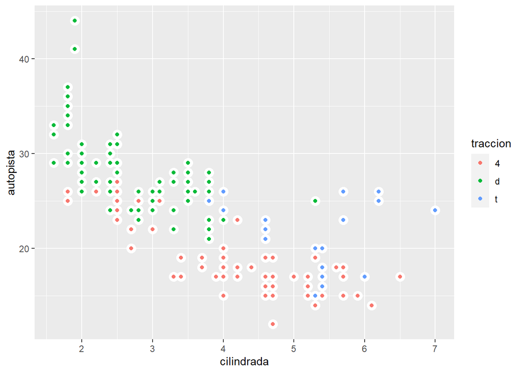

```r
# Sexto gráfico
ggplot(data = millas, mapping = aes(x = cilindrada, y = autopista)) +
   geom_point(size = 4, colour = "white") +
   geom_point(aes(colour = traccion))
```

## Transformaciones estadísticas

##### 3.7.1 Ejercicios

Trabajamos con el conjunto de datos diamantes. Tenemos 53 940 observaciones y 10 variables; 3 variables categóricas, corte, color, claridad, y 7 variables numericas continuas, precio, quilate, profundidad, tabla, x, y, z.

```r
str(diamantes)
```

```
## tibble [53,940 x 10] (S3: tbl_df/tbl/data.frame)
##  $ precio     : int [1:53940] 326 326 327 334 335 336 336 337 337 338 ...
##  $ quilate    : num [1:53940] 0.23 0.21 0.23 0.29 0.31 0.24 0.24 0.26 0.22 0.23 ...
##  $ corte      : Ord.factor w/ 5 levels "Regular"<"Bueno"<..: 5 4 2 4 2 3 3 3 1 3 ...
##  $ color      : Ord.factor w/ 7 levels "D"<"E"<"F"<"G"<..: 2 2 2 6 7 7 6 5 2 5 ...
##  $ claridad   : Ord.factor w/ 8 levels "I1"<"SI2"<"SI1"<..: 2 3 5 4 2 6 7 3 4 5 ...
##  $ profundidad: num [1:53940] 61.5 59.8 56.9 62.4 63.3 62.8 62.3 61.9 65.1 59.4 ...
##  $ tabla      : num [1:53940] 55 61 65 58 58 57 57 55 61 61 ...
##  $ x          : num [1:53940] 3.95 3.89 4.05 4.2 4.34 3.94 3.95 4.07 3.87 4 ...
##  $ y          : num [1:53940] 3.98 3.84 4.07 4.23 4.35 3.96 3.98 4.11 3.78 4.05 ...
##  $ z          : num [1:53940] 2.43 2.31 2.31 2.63 2.75 2.48 2.47 2.53 2.49 2.39 ...
```

```r
?stat_bin
```

1. ¿Cuál es el geom predeterminado asociado con stat_summary()? ¿Cómo podrías reescribir el gráfico anterior para usar esa función geom en lugar de la función stat? La geometría predeterminada asociada con stat_summary() es geom_pointrange()

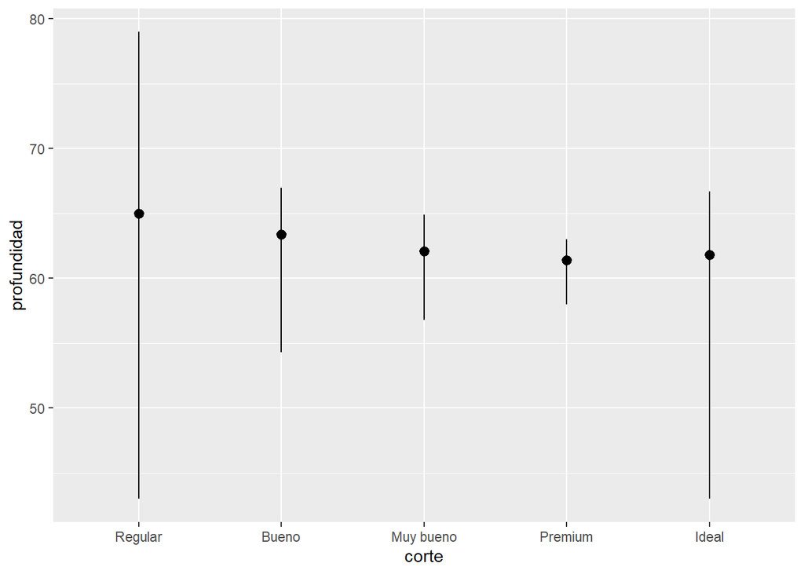

```r
ggplot(data = diamantes) +
  stat_summary(
    mapping = aes(x = corte, y = profundidad),
    fun.min = min,
    fun.max = max,
    fun = median
  )
```

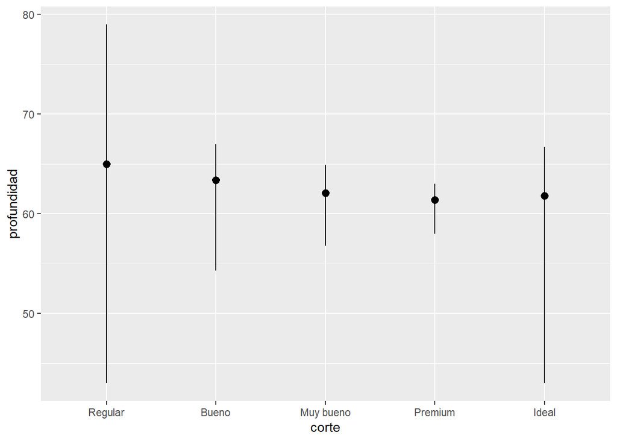

```r
ggplot(data = diamantes) +
  geom_pointrange(mapping = aes(x = corte, y = profundidad),
    stat = "summary",
    fun.min = min,
    fun.max = max,
    fun = median
  )
```

2. ¿Qué hace geom_col()? ¿En qué se diferencia de geom_bar()?

```r
?geom_col
```

Ambos, geom_bar() y geom_col() realizan gráficos de barras. geom_bar() hace que la altura de la barra sea proporcional al número de casos en cada grupo. geom_col() hace que la altura de las barras representen valores en los datos, usa_identity(), emplea los datos como estan. Mientras que, geom_bar() usa stat_count() por defecto, es decir cuenta el número de casos en cada posición, por lo que la altura de las barras es proporcional al número de casos.

3. La mayoría de los geoms y las transformaciones estadísticas vienen en pares que casi siempre se usan en conjunto. Lee la documentación y haz una lista de todos los pares.
- geom_bar(), stat_count()
- geom_bin2d(), stat_bin_2d()
- geom_boxplot(), stat_boxplot()
- geom_contour(), stat_contour()
- geom_count(), stat_sum()
- geom_density(), stat_density()
- geom_density_2d(), stat_density_2d()
- geom_hex(), stat_hex()
- geom_freqpoly(), stat_bin()
- geom_histogram(), stat_bin()
- geom_qq_line(), stat_qq_line()
- geom_qq(), stat_qq()
- geom_quantile(), stat_quantile()
- geom_smooth(), stat_smooth()
- geom_violin(), stat_violin()
- geom_sf(), stat_sf()
4. ¿Qué variables calcula stat_smooth()? ¿Qué parámetros controlan su comportamiento? stat_smooth() calcula las siguientes variables:
- y: valor predicho
- ymin: menor valor del intervalo de confianza
- ymax: mayor valor del intervalo de confianza
- se: error estándar Los parámetros que controlan stat_smooth() incluyen
- method: método de suavizado
- formula: fórmula para obtención de la línea de suavizado
- se: para activar los intervalos de confianza
- na.rm sies FALSO, los valores faltantes predeterminados se eliminan con una advertencia. Si es VERDADERO, los valores perdidos se eliminan silenciosamente.
5. En nuestro gráfico de barras de proporción necesitamos establecer group = 1. ¿Por qué? En otras palabras, ¿cuál es el problema con estos dos gráficos? Si quitamos group = 1, todas las barras tienen una altura igual a 1.

```r
ggplot(data = diamantes) +
  geom_bar(mapping = aes(x = corte, y = stat(prop),group = 1))
```

[output not shown]

```r
ggplot(data = diamantes) +
  geom_bar(mapping = aes(x = corte, y = stat(prop)))
```

[output not shown]

```r
ggplot(data = diamantes) +
  geom_bar(mapping = aes(x = corte, y = ..prop.., group = 1))
```

[output not shown]

```r
ggplot(data = diamantes) +
  geom_bar(mapping = aes(x = corte, y = ..prop..))
```

[output not shown]

```r
ggplot(data = diamantes) +
  geom_bar(mapping = aes(x = corte, y = after_stat(prop)))
```

[output not shown]

```r
ggplot(data = diamantes) +
  geom_bar(mapping = aes(x = corte, y = after_stat(prop), group = 1))
```

[output not shown]

No ocurre igual con el argumento fill. Stat cuando una expresión estética que utiliza variables de los datos de la capa y after_stat utiliza variables calculadas por stat. Si usamos el argumento fill debe tomar la variable calculada o realizarse el calculo en el código.

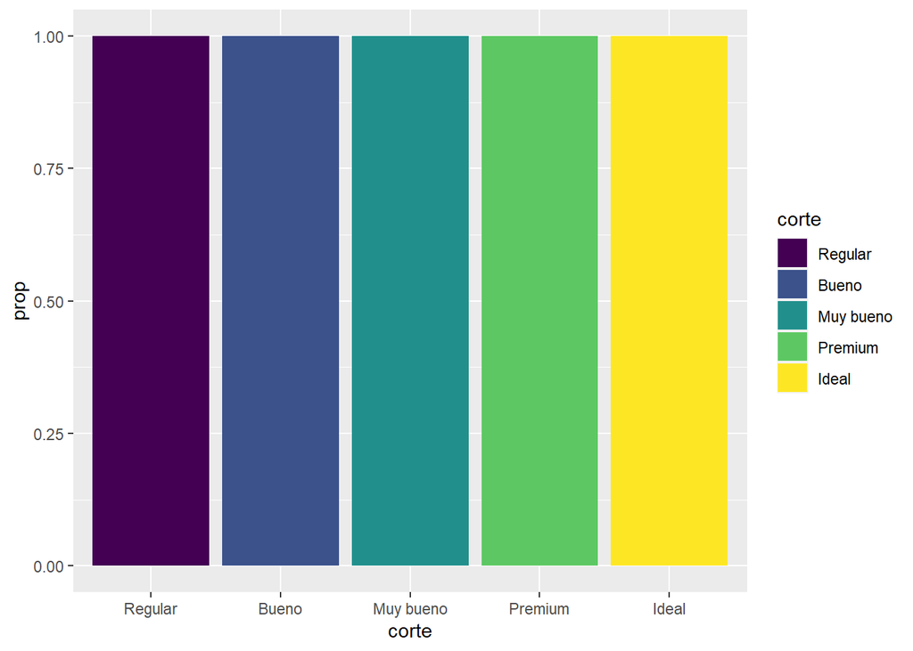

```r
ggplot(data = diamantes) +
  geom_bar(mapping = aes(x = corte, fill = corte, y = after_stat(prop)))
```

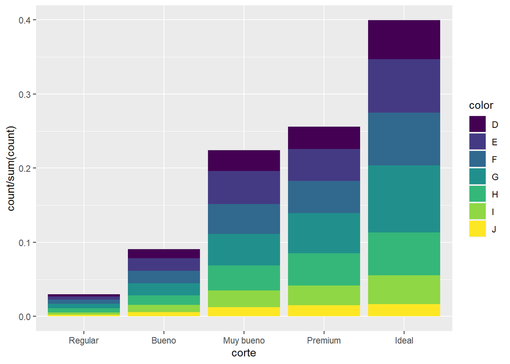

```r
ggplot(data = diamantes) +
  geom_bar(aes(x = corte, y = ..count.. / sum(..count..), fill = color))
```

## Ajuste de posición

##### 3.8.1 Ejercicios

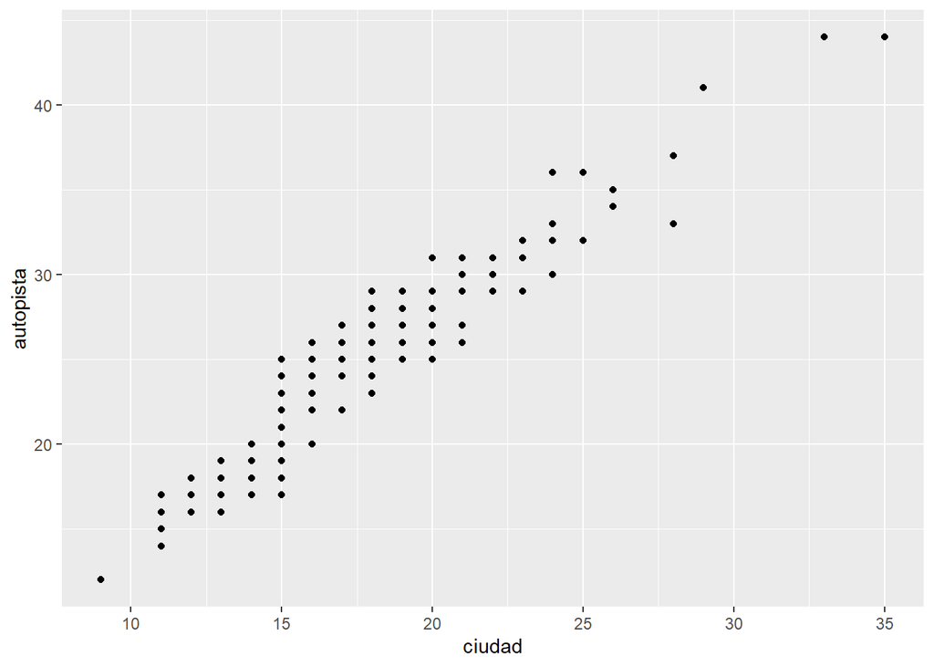

```r
ggplot(data = millas, mapping = aes(x = ciudad, y = autopista)) +
  geom_point()
```

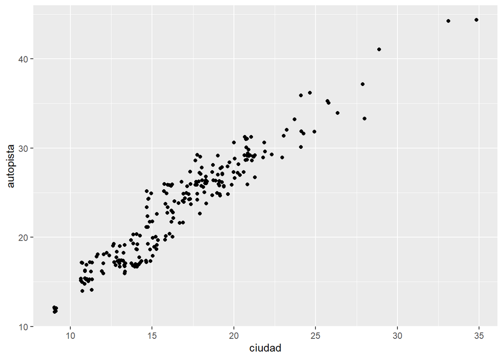

```r
ggplot(data = millas) +
  geom_point(mapping = aes(x = ciudad, y = autopista), position = "jitter")
```

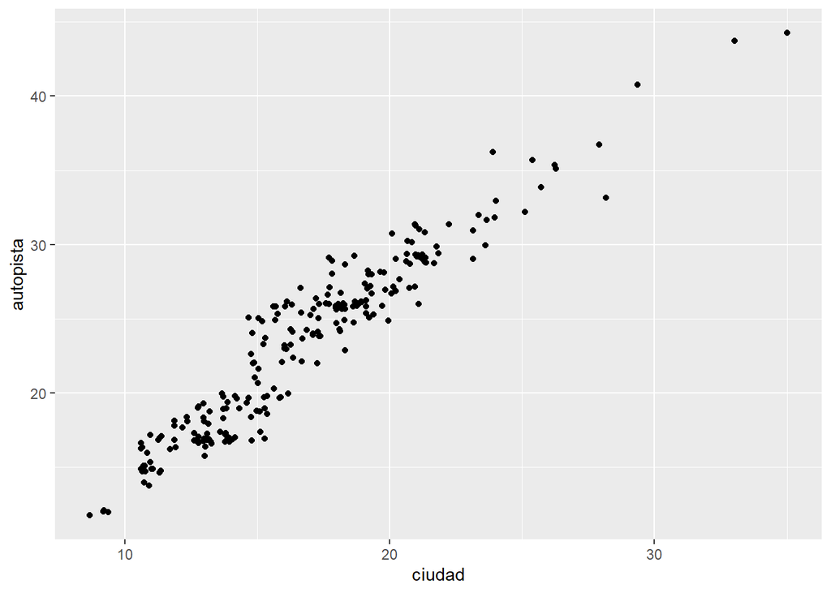

```r
ggplot(data = millas, mapping = aes(x = ciudad, y = autopista)) +
geom_jitter()
```

2. ¿Qué parámetros de geom_jitter() controlan la cantidad de ruido?

```r
?geom_jitter
```

En la documentación de geom_jitter(), podemos ver los argumentos width y height controlan la dispersión en dirección positiva y negativa, a lo andho y largo, respectivamente. Por lo que la dispersión total es el doble del valor especificado en el argumento. Los valores predeterminados son de 0.4 para ambos argumentos, es decir logran una dispersión total del 0.8 a lo ancho y largo. Supongamos que sólo queremos una dispersión horizontal y al revés.

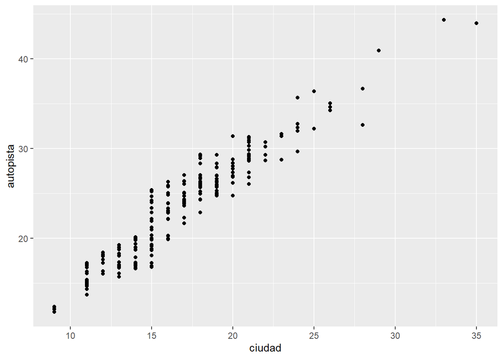

```r
ggplot(data = millas, mapping = aes(x = ciudad, y = autopista)) +
  geom_jitter(width = 0)
```

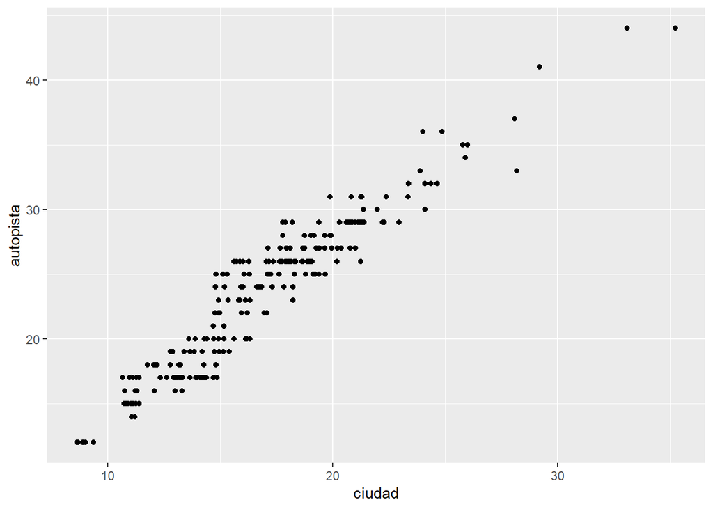

```r
ggplot(data = millas, mapping = aes(x = ciudad, y = autopista)) +
  geom_jitter(height = 0)
```

3. Compara y contrasta geom_jitter() con geom_count() Observamos que geom_count() cambia el tamaño de los puntos relativo a la cantidad de observaciones. Las combinaciones de x e y con más observaciones tendrán un mayor tamaño. Esto no distorsiona los valores, pero tiene el problema de que el tamaño de los puntos puede generar superposición si los puntos son cercanos.

```r
?geom_count
```

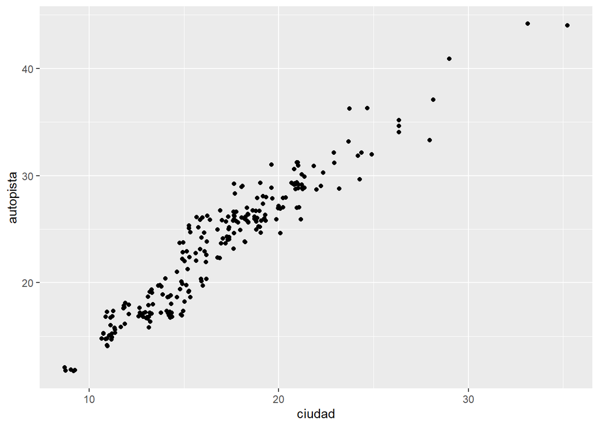

```r
ggplot(data = millas, mapping = aes(x = ciudad, y = autopista)) +
  geom_jitter()
```

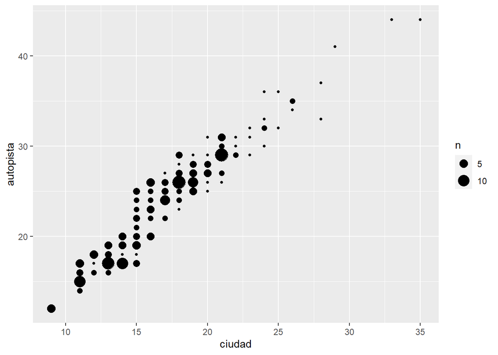

```r
ggplot(data = millas, mapping = aes(x = ciudad, y = autopista)) +
  geom_count()
```

4. ¿Cuál es el ajuste de posición predeterminado de geom_boxplot()? Crea una visualización del conjunto de datos de millas que lo demuestre.

```r
?position_dodge2()
```

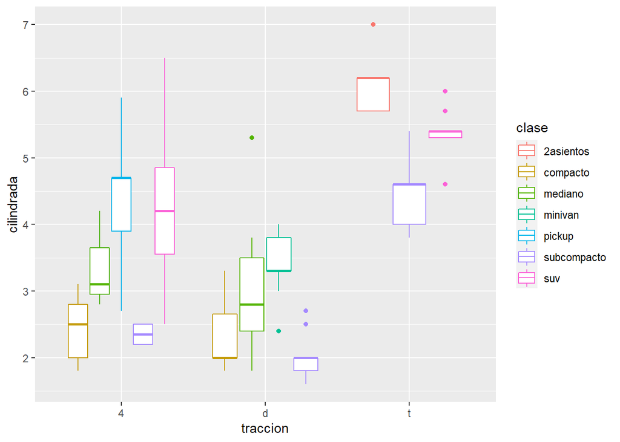

```r
ggplot(data = millas, aes(x = traccion, y = cilindrada, colour = clase)) +
  geom_boxplot()
```

## Sistema de coordenadas

##### 3.9.1 Ejercicios

1. Convierte un gráfico de barras apiladas en un gráfico circular usando coord_polar(). Tomamos el gráfico de barras apilado del apartado 3.8 Ajuste de posición.

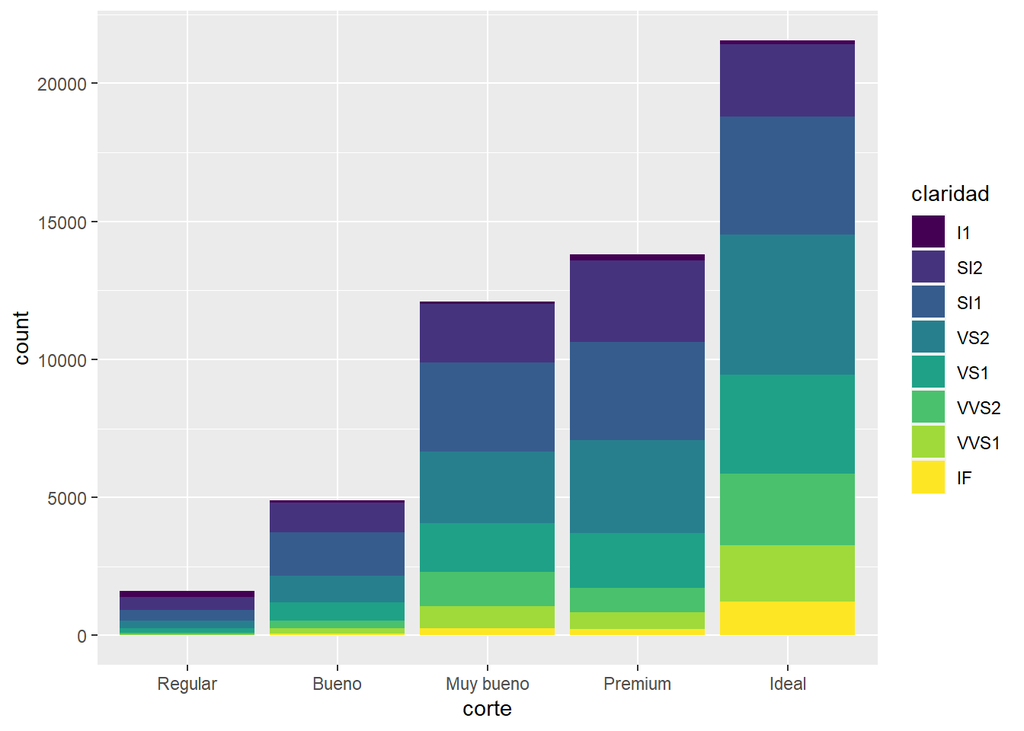

```r
ggplot(data = diamantes) +
  geom_bar(mapping = aes(x = corte, fill = claridad))
```

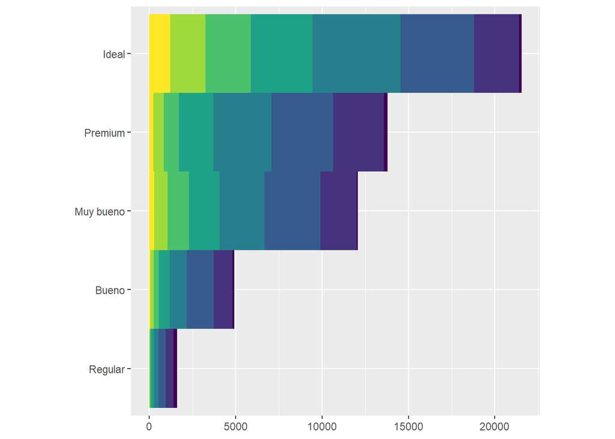

```r
bar <- ggplot(data = diamantes) +
  geom_bar(
    mapping = aes(x = corte , fill = claridad),
    show.legend = FALSE,
    width = 1
  ) +
  theme(aspect.ratio = 1) +
  labs(x = NULL, y = NULL)

bar + coord_flip()
```

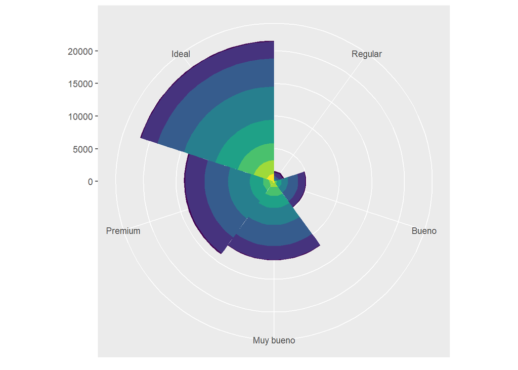

```r
bar + coord_polar()
```

2. ¿Qué hace labs()? Lee la documentación. labs agrega los títulos de los ejes, título del gráfico y la leyenda. Lo aplicamos para los gráficos del punto anterior.

```r
?labs()
```

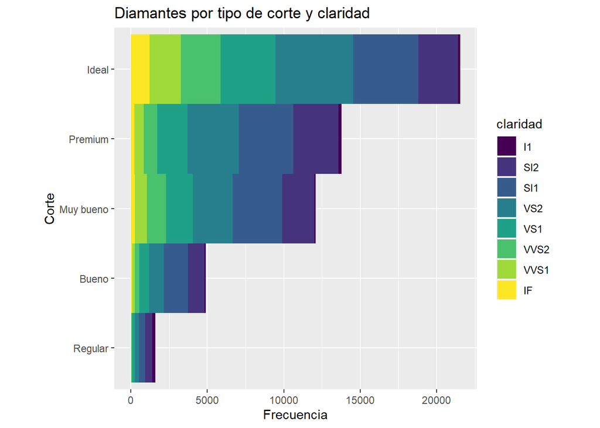

```r
bar <- ggplot(data = diamantes) +
  geom_bar(
    mapping = aes(x = corte , fill = claridad),
    show.legend = T,
    width = 1
  ) +
  theme(aspect.ratio = 1) +
  labs(x = "Corte", y = "Frecuencia", title = "Diamantes por tipo de corte y claridad")

bar + coord_flip()
```

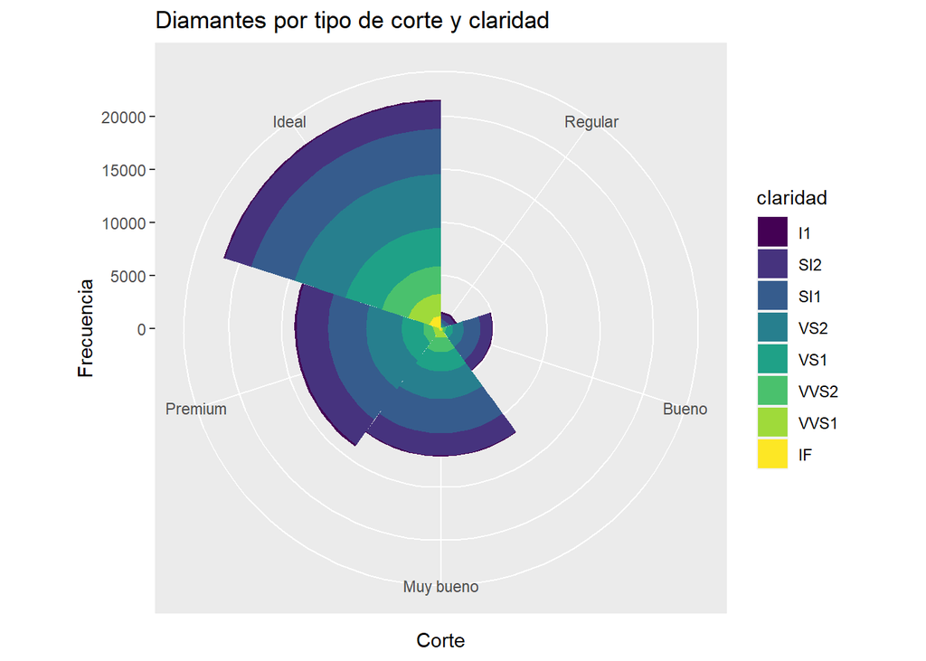

```r
bar + coord_polar()
```

3. ¿Cuál es la diferencia entre coord_quickmap() y coord_map()?

```r
?coord_quickmap
```

- coord_map() realiza una proyección cartográfica de la Tierra, que es aproximadamente esférica, en un plano plano 2D utilizando cualquier proyección definida por el paquete mapproj. Las proyecciones de mapas, en general, no conservan las líneas rectas, por lo que esto requiere un cálculo considerable.
- coord_quickmap() es una aproximación rápida que conserva las líneas rectas. Funciona mejor para áreas más pequeñas cerca del ecuador.
4. ¿Qué te dice la gráfica siguiente sobre la relación entre ciudad y autopista? ¿Por qué es coord_fixed() importante? ¿Qué hace geom_abline()? Los geom_adline, geom_hline, geom_vline, agregan líneas de referencia, diagonal, horizontal, vertical respectivamente, a una parcela. La función coord_fixed() asegura que la línea que genera geom_abline() tenga un ángulo de 45 grados. De este modo es más fácil comparar a partir de los casos en que los rendimientos en autopista y ciudad son iguales.

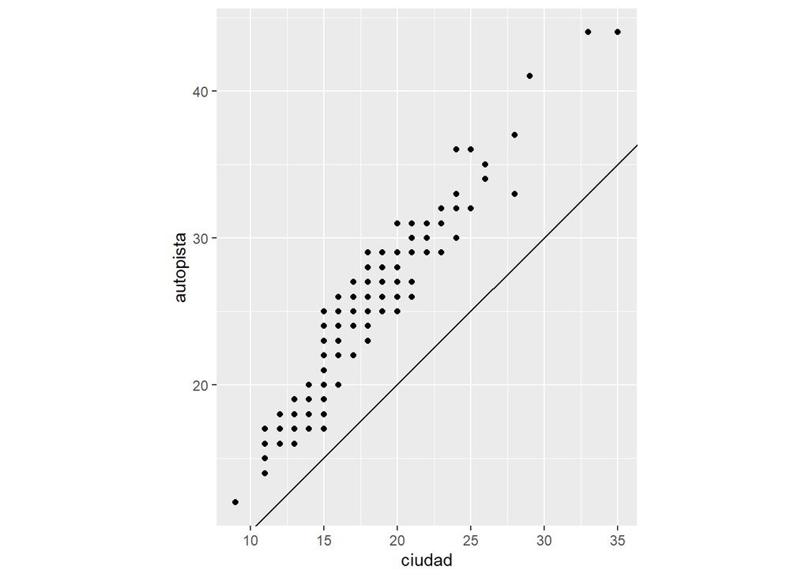

```r
ggplot(data = millas, mapping = aes(x = ciudad, y = autopista)) +
  geom_point() +
  geom_abline() +
  coord_fixed()
```